# Neptune City School District — NJ School Data Almanac – NJ District Profiles

NJ School Data Almanac

Neptune City School District

MONMOUTH COUNTY · TRADITIONAL PUBLIC DISTRICT · DFG CD · 222 STUDENTS (2026)

222

Students

19.4%

Gr 3-8 ELA

30.8%

Chronically absent

$19,824

Per pupil

*7 things the data says about Neptune City School District. Every figure is computed from New Jersey Department of Education data via the njschooldata package — nothing is estimated. Comparisons use District Factor Group (DFG) peers (67 districts in DFG CD).*

No. 1 ACHIEVEMENT

The 2024 ELA figure is the lowest in the district’s available record, below even the immediate post-pandemic mark. That breaks the recovery pattern that defined most of the state and raises a hard question the test scores alone cannot answer: what is driving a decline that has continued well past the years when classrooms reopened?

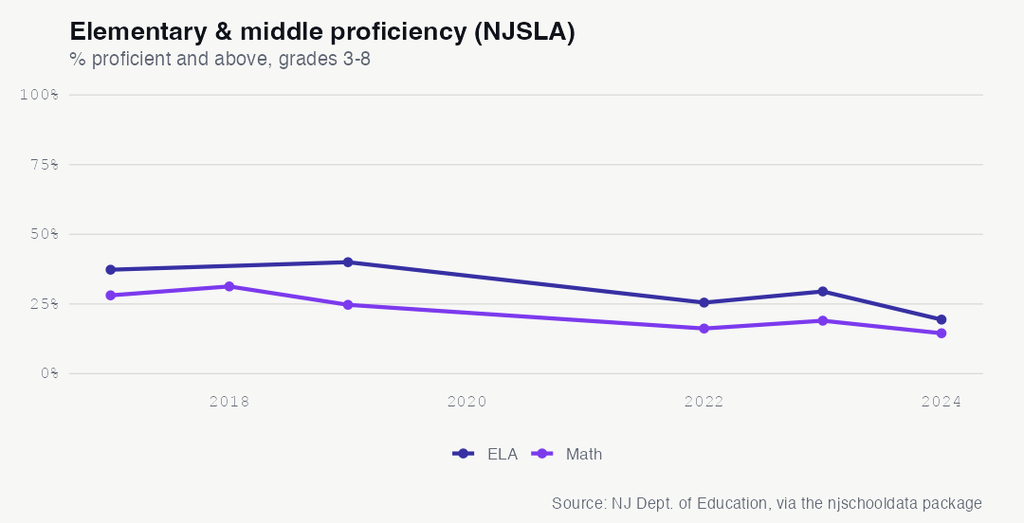

See the underlying data ›

No. 2 EQUITY

## In Neptune City, Black Students Out-Read Hispanic Peers 22.7% to 9.3% on the 2024 State Test

On the 2024 grades 3-8 NJSLA English language arts test, 22.7% of Neptune City’s Black students scored proficient, against 9.3% of Hispanic students, a gap of more than 13 points that runs counter to statewide patterns where Hispanic and Black proficiency often track more closely. Boys outscored girls as well, 23.1% to 17.2%, another reversal of the typical direction.

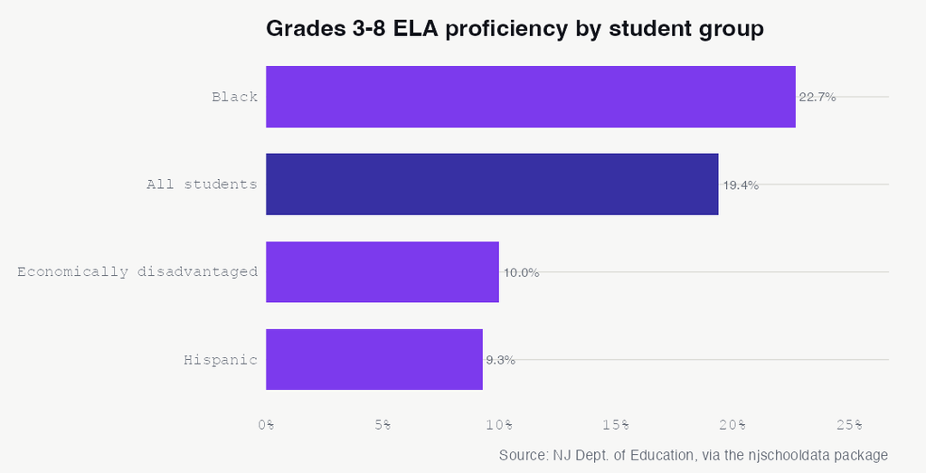

See the underlying data ›

No. 3 ATTENDANCE

## 30.8% of Neptune City Students Were Chronically Absent in 2024, More Than Double the Peer Median

Chronic absenteeism nearly doubled from its pre-pandemic level and ran well above similar New Jersey districts.

In 2019, 17.1% of Neptune City students were chronically absent, meaning they missed at least 10% of the school year. By 2024 that share had climbed to 30.8%, nearly doubling, and it sat more than twice the median of 14.6% among the district’s District Factor Group CD peers.

The trajectory was not a steady climb. The rate dipped to 15% in 2021, then jumped to 27.4% in 2022 as schools returned to full in-person instruction, eased to 23% in 2023, and rose again to its 2024 high. That up-and-down pattern points to a problem that has not settled into a recovery.

Chronic absenteeism is among the strongest early-warning signals in education data, because students who are chronically absent fall behind regardless of what happens in the classroom. The timing lines up with the district’s reading decline through 2024. With nearly one in three students missing significant instruction, what would it take for Neptune City to pull its rate back toward the 17% it posted before the pandemic, let alone the peer median below it?

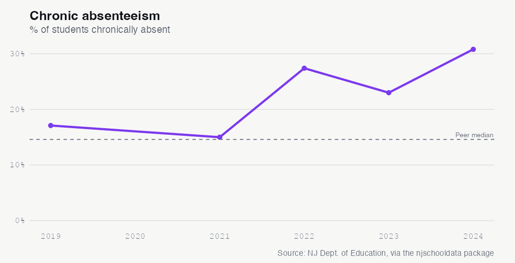

See the underlying data ›

No. 4 ENROLLMENT

## Neptune City’s Enrollment Has Fallen 41% Since 2015, and 2026 Erased a Three-Year Rebound

After climbing back from a pandemic-era low, the K-8 shore district lost 43 students in a single year, dropping to 222.

Neptune City School District enrolled 379 students in 2015. By 2021 that count had fallen to 219, a trough reached after six straight years of decline. Then the district did something unusual for a shrinking shore system: it grew, adding students three years running to reach 280 by 2024.

The rebound did not hold. Enrollment slipped to 265 in 2025 and then fell 16.2% in 2026, a loss of 43 students, landing at 222. That leaves the district almost exactly where it sat at its 2021 low and down 157 students, or 41.4%, from its 2015 starting point.

For a district this small, a swing of 43 students is roughly a fifth of the entire student body in one year. The 2022-2024 recovery suggested the slide had bottomed out; the 2026 drop reopens the question. Was the rebound a temporary reversal in a long structural decline, or is the 2026 figure the anomaly the district can climb back from again?

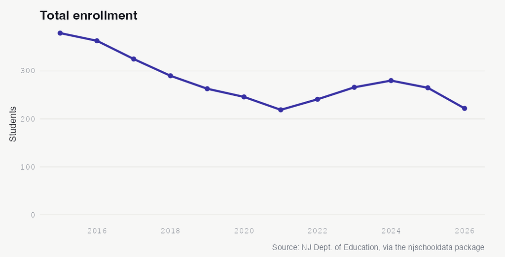

See the underlying data ›

No. 5 DEMOGRAPHICS

## Neptune City’s White Enrollment Share Fell to 21% by 2021, Then Climbed Back to 29% in 2026

A decade of demographic change saw the white share drop nearly 25 points before partially reversing, as Hispanic enrollment rose and then receded.

In 2015, white students made up 45.9% of Neptune City’s enrollment. Over the next six years that share fell steadily to 21% in 2021, the largest demographic shift in the district. Hispanic enrollment moved in the opposite direction over the same stretch, rising from 23.2% in 2015 to a peak of 41.1% in 2022.

Then the lines began to converge again. By 2026 the white share had recovered to 29.3% while the Hispanic share eased back to 33.3%. The Black share stayed comparatively steady across the decade, ranging from 25.1% in 2015 to 28.4% in 2026, and students identifying as multiracial grew from 1.1% to 5.9%.

The net change since 2015 still tells a clear story: white down 16.6 points, Hispanic up 10.1 points, multiracial up 4.8 points. But the recent reversal complicates the simple narrative of one-directional change. With overall enrollment swinging sharply in the same years, is the 2026 rebound in white share a lasting shift or a byproduct of which families happened to enroll in a much smaller district?

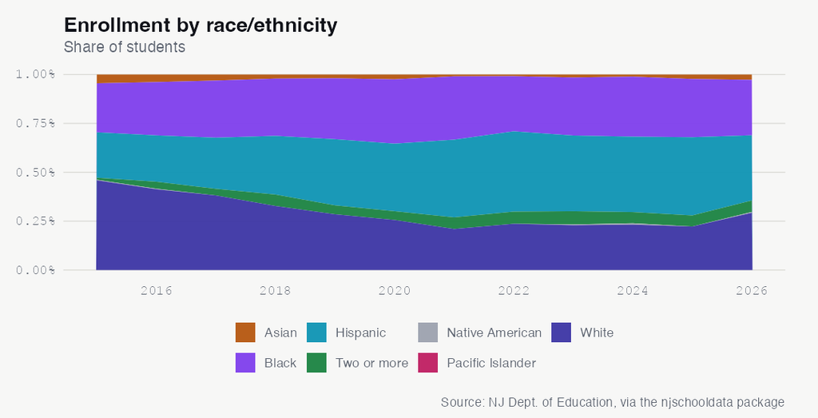

See the underlying data ›

No. 6 FINANCE

## Neptune City Spends $19,824 Per Pupil, 83% More Than in 2014 as Enrollment Shrank

Per-pupil spending rose to the 72nd percentile among peers even as the number of students to spread fixed costs across fell sharply.

Neptune City spent $10,852 per pupil in 2014. A decade later, in 2024, it spent $19,824, an 82.7% increase that placed it at the 72nd percentile among its District Factor Group CD peers, above the peer median of $18,350.

That rise tracks closely with the district’s shrinking enrollment. Average daily enrollment fell from 396 students in 2014 to a low of 220 in 2023 before recovering to 291 in 2024. When fixed costs such as building operations, administration, and staffing are spread across fewer students, per-pupil figures climb even if total spending holds. The per-pupil number itself was volatile, spiking to $23,625 in 2023, the year enrollment bottomed, then falling back as students returned.

The spending mix in 2025 sent most dollars to the classroom: 53.9% on classroom instruction, 28.4% on support services, 9.3% on plant operations, and 7.1% on administration. With reading proficiency at 19.4% and chronic absenteeism above 30%, the open question is whether high per-pupil spending is translating into the outcomes a small-district premium is supposed to buy.

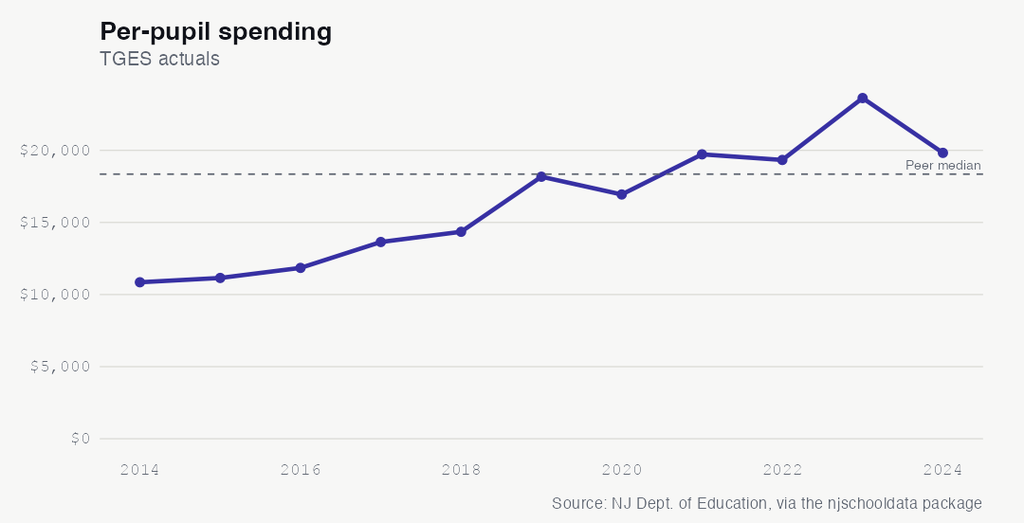

See the underlying data ›

No. 7 EQUITY

## Neptune City’s English Learner Share Tripled to 13.6% by 2024 Before Easing to 8.6%

The count of students learning English rose and fell sharply in a district where economic need has stayed high.

Students classified as English learners made up 4.7% of Neptune City’s enrollment in 2015. That share roughly tripled over the next decade, peaking at 13.6%, or 38 students, in 2024, before easing to 8.6% in 2026. The rise paralleled the growth in the district’s Hispanic enrollment over the same period.

Economic need has remained a defining feature of the district throughout. The share of students qualifying for free or reduced-price lunch ranged from 45.6% in 2022 to a high of 63.4% in 2020, and stood at 48.6% in 2026. Across the decade, roughly half or more of Neptune City students came from economically disadvantaged households in most years.

The English learner count is small enough that a handful of families can move the percentage by several points, which makes the swings hard to read. As the district’s demographics keep shifting, will the supports built for a growing English learner population stay matched to a number that has proven this volatile?

See the underlying data ›

## The Almanac

The full longitudinal record behind the stories above. Every number a reader can check.

### Enrollment (total)

| year | students | yoy | yoy_pct |
| --- | --- | --- | --- |
| 2015 | 379 | NA | NA |
| 2016 | 363 | -16 | -4.2 |
| 2017 | 325 | -38 | -10.5 |
| 2018 | 290 | -35 | -10.8 |
| 2019 | 263 | -27 | -9.3 |
| 2020 | 246 | -17 | -6.5 |
| 2021 | 219 | -27 | -11 |
| 2022 | 241 | 22 | 10 |
| 2023 | 266 | 25 | 10.4 |
| 2024 | 280 | 14 | 5.3 |
| 2025 | 265 | -15 | -5.4 |
| 2026 | 222 | -43 | -16.2 |

### Demographic share (%) by year

| end_year | white | black | hispanic | asian | native_american | pacific_islander | multiracial |
| --- | --- | --- | --- | --- | --- | --- | --- |
| 2015 | 45.9 | 25.1 | 23.2 | 4.5 | 0.3 | 0 | 1.1 |
| 2016 | 41.3 | 27.3 | 23.7 | 3.9 | 0.3 | 0 | 3.6 |
| 2017 | 38.2 | 29.2 | 26.2 | 3.1 | 0 | 0 | 3.4 |
| 2018 | 32.8 | 29.3 | 30 | 2.1 | 0 | 0 | 5.9 |
| 2019 | 28.5 | 31.2 | 33.8 | 1.9 | 0 | 0 | 4.6 |
| 2020 | 25.6 | 32.9 | 34.6 | 2.4 | 0 | 0 | 4.5 |
| 2021 | 21 | 32.4 | 39.7 | 0.9 | 0 | 0 | 5.9 |
| 2022 | 23.7 | 28.2 | 41.1 | 0.8 | 0 | 0 | 6.2 |
| 2023 | 22.9 | 29.7 | 38.7 | 1.5 | 0.4 | 0 | 6.8 |
| 2024 | 23.2 | 30.7 | 38.6 | 1.1 | 0.7 | 0 | 5.7 |
| 2025 | 22.3 | 29.8 | 40 | 2.3 | 0 | 0 | 5.7 |
| 2026 | 29.3 | 28.4 | 33.3 | 2.7 | 0.5 | 0 | 5.9 |

### Special populations (LEP, FRL)

| end_year | subgroup | students | pct |
| --- | --- | --- | --- |
| 2015 | lep | 18 | 4.7 |
| 2015 | free_reduced_lunch | 202 | 53.3 |
| 2016 | lep | 17 | 4.7 |
| 2016 | free_reduced_lunch | 207 | 57.0 |
| 2017 | lep | 20 | 6.2 |
| 2017 | free_reduced_lunch | 191 | 58.8 |
| 2018 | lep | 23 | 7.9 |
| 2018 | free_reduced_lunch | 173 | 59.7 |
| 2019 | lep | 28 | 10.6 |
| 2019 | free_reduced_lunch | 146 | 55.5 |
| 2020 | lep | 30 | 12.2 |
| 2020 | free_reduced_lunch | 156 | 63.4 |
| 2021 | lep | 17 | 7.8 |
| 2021 | free_reduced_lunch | 131 | 59.8 |
| 2022 | lep | 15 | 6.2 |
| 2022 | free_reduced_lunch | 110 | 45.6 |
| 2023 | lep | 28 | 10.5 |
| 2023 | free_reduced_lunch | 129 | 48.5 |
| 2024 | lep | 38 | 13.6 |
| 2024 | free_reduced_lunch | 131 | 46.8 |
| 2025 | lep | 32 | 12.1 |
| 2025 | free_reduced_lunch | 148 | 55.9 |
| 2026 | lep | 19 | 8.6 |
| 2026 | free_reduced_lunch | 108 | 48.6 |

### NJSLA grades 3-8 proficiency (% proficient+, enrollment-weighted across grades)

| testing_year | test_name | prof |
| --- | --- | --- |
| 2017 | ela | 37.3 |
| 2017 | math | 28.1 |
| 2018 | math | 31.3 |
| 2019 | ela | 40.0 |
| 2019 | math | 24.7 |
| 2022 | ela | 25.5 |
| 2022 | math | 16.2 |
| 2023 | ela | 29.5 |
| 2023 | math | 19.0 |
| 2024 | ela | 19.4 |
| 2024 | math | 14.5 |

### NJSLA ELA proficiency by subgroup (2024, grades 3-8)

| subgroup | prof |
| --- | --- |
| male | 23.1 |
| black | 22.7 |
| total_population | 19.4 |
| female | 17.2 |
| non_ed | 16.7 |
| ed | 10.0 |
| sped_accomodations | 10.0 |
| hispanic | 9.3 |

### Chronic absenteeism (% chronically absent)

| year | chronic_pct |
| --- | --- |
| 2019 | 17.1 |
| 2021 | 15 |
| 2022 | 27.4 |
| 2023 | 23 |
| 2024 | 30.8 |

### Disciplinary removals

[output not shown]

### Police notifications (incident counts)

| year | violence | weapons | vandalism | substances | hib | other |
| --- | --- | --- | --- | --- | --- | --- |
| 2019 | 0 | 0 | 0 | 0 | 1 | 0 |
| 2020 | 0 | 0 | 0 | 0 | 0 | 0 |
| 2021 | 1 | 0 | 0 | 0 | 0 | 0 |
| 2022 | 2 | 1 | 0 | 0 | 0 | 0 |
| 2023 | 3 | 0 | 0 | 0 | 0 | 2 |
| 2024 | 5 | 0 | 0 | 0 | 0 | 0 |

### HIB (harassment/intimidation/bullying) investigations

| end_year | alleged | confirmed |
| --- | --- | --- |
| 2019 | 0 | 1 |
| 2020 | 0 | 0 |
| 2021 | 0 | 0 |
| 2022 | 0 | 0 |
| 2023 | 1 | 0 |
| 2024 | 3 | 2 |

### Special education (raw rows; inspect for classification rate)

| end_year | district_id |
| --- | --- |
| 2024 | 3500 |

### Per-pupil spending (TGES actuals)

| year | per_pupil | rank | ade |
| --- | --- | --- | --- |
| 2014 | 10852 | 3 | 396 |
| 2015 | 11150 | 3 | 379 |
| 2016 | 11848 | 3 | 363 |
| 2017 | 13643 | 12 | 318 |
| 2018 | 14352 | 13 | 309 |
| 2019 | 18171 | 36 | 257 |
| 2020 | 16939 | 29 | 259 |
| 2021 | 19722 | 43 | 221 |
| 2022 | 19333 | 40 | 241 |
| 2023 | 23625 | 51 | 220 |
| 2024 | 19824 | 28 | 291 |

### Spending composition shares (2025)

| classroom_share | support_services_share | administration_share | plant_ops_share | food_service_share | extracurricular_share | equipment_share |
| --- | --- | --- | --- | --- | --- | --- |
| 53.9 | 28.4 | 7.1 | 9.3 | NA | 1.3 | 0.2 |

### Staffing ratios

| end_year | student_teacher_district | student_admin_district | student_counselor_district | student_nurse_district |
| --- | --- | --- | --- | --- |
| 2024 | 9:1 | 91:1 | NA | 274:1 |

Back to top